# Fishing Activity in the Antarctic Peninsula

State of the Antarctic Environment report

Author

Pablo Deschepper (biodiversity.aq) - Institute for Natural Sciences, Belgium

Published

April 9, 2026

# 1 Introduction

This chapter presents spatiotemporal data products on commercial fishing activity in the Antarctic Peninsula. Data are sourced from the **Global Fishing Watch (GFW)** open API (v3), which detects *apparent fishing effort* by analysing AIS vessel broadcasts and classifying positions as fishing or non-fishing based on changes in speed and heading. Effort is expressed as **fishing hours** per 0.1° × 0.1° grid cell.

**Note**

**Data caveats:** AIS coverage approaches ~90% for vessels >24 m but is substantially lower for smaller vessels. Results represent a lower bound on total fishing activity.

# 2 Annual Fishing Hotspot Heatmaps (last 10 years)

## 2.1 Heatmap visualisation

[figure not shown]

Figure 1: Annual fishing effort hotspots in the Antarctic Peninsula. Colour encodes apparent fishing hours per 0.1° grid cell on a log₁₀ scale; all panels share the same colour axis for direct comparison.

# 3 Temporal Evolution of Fishing Intensity from 2016 to 2025

# 4 Annual and monthly trends in fisheries intensities

[figure not shown]

Figure 2: (A) Annual fishing effort totals and (B) month-by-year anomaly heatmap.

# 5 Gear-type composition over time

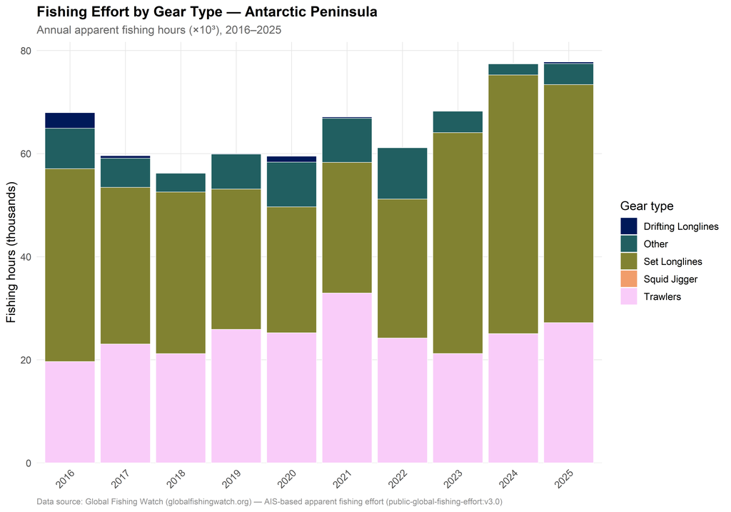

Figure 3: Annual fishing effort by gear type in the Antarctic Peninsula.

**Reproducibility & troubleshooting**

**Cache files** in the working directory:

- `cache_heatmap_data.rds` — annual gridded effort (heatmaps + gear plot)
- `cache_trend_data.rds` — monthly effort time series (trend section)

The notebook validates the cache on load and **automatically deletes and re-fetches** if the file is empty or corrupt. To force a full refresh, delete both `.rds` files before rendering.

**If fetches keep failing:**

1. Run `print_request = TRUE` in a manual `gfw_ais_fishing_hours()` call to see the exact URL being sent to the API.
2. Test the request interactively in R and check for HTTP 524 (timeout) or HTTP 429 (rate limit). For 429, wait ~90 seconds and re-render.
3. Contact GFW support at apis@globalfishingwatch.org with the printed request URL.